# BI-2019 Statistics Project №2

# 1 Полная линейная модель (Обязательная часть)

## 1.1 Построение модели

Для начала, подгрузим данные и взглянем на них. Также посмотрим и на спецификацию датасета. Увидим, что переменные rad и chas являются факторными переменными. Учтём это.

```r
summary(Boston)
```

```
##       crim                zn             indus            chas
##  Min.   : 0.00632   Min.   :  0.00   Min.   : 0.46   Min.   :0.00000
##  1st Qu.: 0.08204   1st Qu.:  0.00   1st Qu.: 5.19   1st Qu.:0.00000
##  Median : 0.25651   Median :  0.00   Median : 9.69   Median :0.00000
##  Mean   : 3.61352   Mean   : 11.36   Mean   :11.14   Mean   :0.06917
##  3rd Qu.: 3.67708   3rd Qu.: 12.50   3rd Qu.:18.10   3rd Qu.:0.00000
##  Max.   :88.97620   Max.   :100.00   Max.   :27.74   Max.   :1.00000
##       nox               rm             age              dis
##  Min.   :0.3850   Min.   :3.561   Min.   :  2.90   Min.   : 1.130
##  1st Qu.:0.4490   1st Qu.:5.886   1st Qu.: 45.02   1st Qu.: 2.100
##  Median :0.5380   Median :6.208   Median : 77.50   Median : 3.207
##  Mean   :0.5547   Mean   :6.285   Mean   : 68.57   Mean   : 3.795
##  3rd Qu.:0.6240   3rd Qu.:6.623   3rd Qu.: 94.08   3rd Qu.: 5.188
##  Max.   :0.8710   Max.   :8.780   Max.   :100.00   Max.   :12.127
##       rad              tax           ptratio          black
##  Min.   : 1.000   Min.   :187.0   Min.   :12.60   Min.   :  0.32
##  1st Qu.: 4.000   1st Qu.:279.0   1st Qu.:17.40   1st Qu.:375.38
##  Median : 5.000   Median :330.0   Median :19.05   Median :391.44
##  Mean   : 9.549   Mean   :408.2   Mean   :18.46   Mean   :356.67
##  3rd Qu.:24.000   3rd Qu.:666.0   3rd Qu.:20.20   3rd Qu.:396.23
##  Max.   :24.000   Max.   :711.0   Max.   :22.00   Max.   :396.90
##      lstat            medv
##  Min.   : 1.73   Min.   : 5.00
##  1st Qu.: 6.95   1st Qu.:17.02
##  Median :11.36   Median :21.20
##  Mean   :12.65   Mean   :22.53
##  3rd Qu.:16.95   3rd Qu.:25.00
##  Max.   :37.97   Max.   :50.00
```

Стандартизируем наши переменные и представим rad и chas в факторном виде.

```r
boston_standart <- as.data.frame(sapply(Boston, scale))
boston_standart$chas <- as.factor(Boston$chas)
boston_standart$rad <- as.factor(Boston$rad)
```

Посмотрим на коллинеарности:

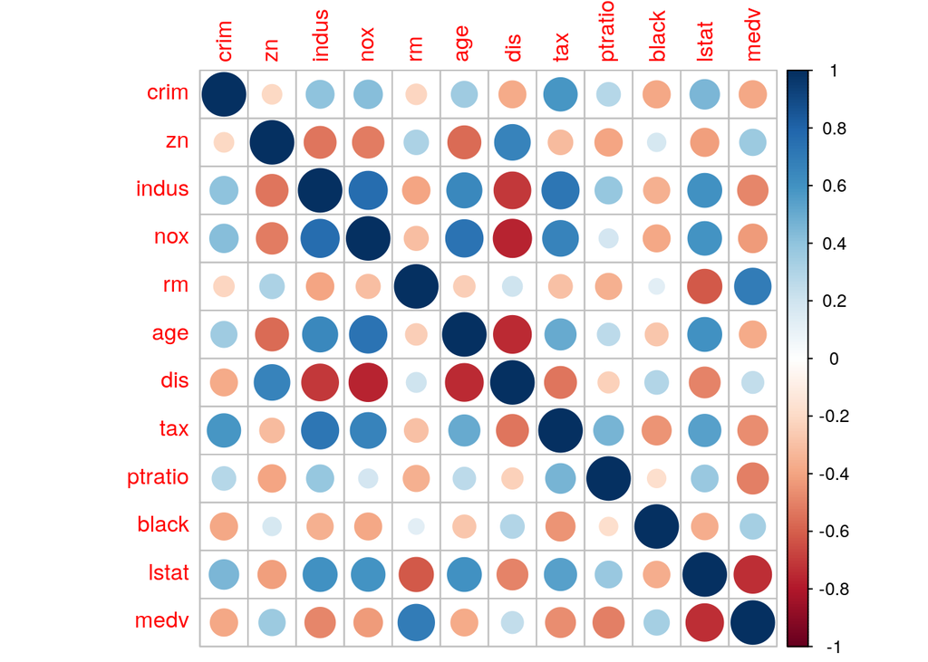

```r
mat <- cor(boston_standart[ , purrr::map_lgl(boston_standart, is.numeric)])
corrplot(mat)
```

Построим нашу полную линейную модель без учёта наличия коллинеарностей и взглянем на её summary.

```r
full_model <- lm(medv ~ ., boston_standart)
summary(full_model)
```

```
##
## Call:
## lm(formula = medv ~ ., data = boston_standart)
##
## Residuals:
##      Min       1Q   Median       3Q      Max
## -1.64204 -0.29743 -0.04963  0.18289  2.82100
##
## Coefficients:
##              Estimate Std. Error t value Pr(>|t|)
## (Intercept) -0.458954   0.125554  -3.655 0.000285 ***
## crim        -0.101774   0.030569  -3.329 0.000937 ***
## zn           0.139209   0.035880   3.880 0.000119 ***
## indus        0.017723   0.047476   0.373 0.709081
## chas1        0.274452   0.093854   2.924 0.003614 **
## nox         -0.221410   0.049092  -4.510 8.13e-06 ***
## rm           0.280027   0.032177   8.703  < 2e-16 ***
## age          0.001411   0.040482   0.035 0.972210
## dis         -0.355919   0.046228  -7.699 7.75e-14 ***
## rad2         0.161888   0.160649   1.008 0.314095
## rad3         0.508992   0.145187   3.506 0.000498 ***
## rad4         0.280114   0.129102   2.170 0.030514 *
## rad5         0.317327   0.131303   2.417 0.016028 *
## rad6         0.128936   0.159182   0.810 0.418342
## rad7         0.530492   0.170836   3.105 0.002012 **
## rad8         0.526235   0.162188   3.245 0.001257 **
## rad24        0.811307   0.194483   4.172 3.58e-05 ***
## tax         -0.160310   0.071371  -2.246 0.025144 *
## ptratio     -0.228902   0.034009  -6.731 4.78e-11 ***
## black        0.093247   0.026411   3.531 0.000454 ***
## lstat       -0.410916   0.039319 -10.451  < 2e-16 ***
## ---
## Signif. codes:  0 '***' 0.001 '**' 0.01 '*' 0.05 '.' 0.1 ' ' 1
##
## Residual standard error: 0.5103 on 485 degrees of freedom
## Multiple R-squared:  0.7499, Adjusted R-squared:  0.7396
## F-statistic:  72.7 on 20 and 485 DF,  p-value: < 2.2e-16
```

Получили неплохой, но отнюдь не идеальный коэффициент детерминации. Вернёмся к улучшению результатов во второй части работы. А сейчас…

## 1.2 Диагностика модели

### 1.2.1 Проверка графиков остатков

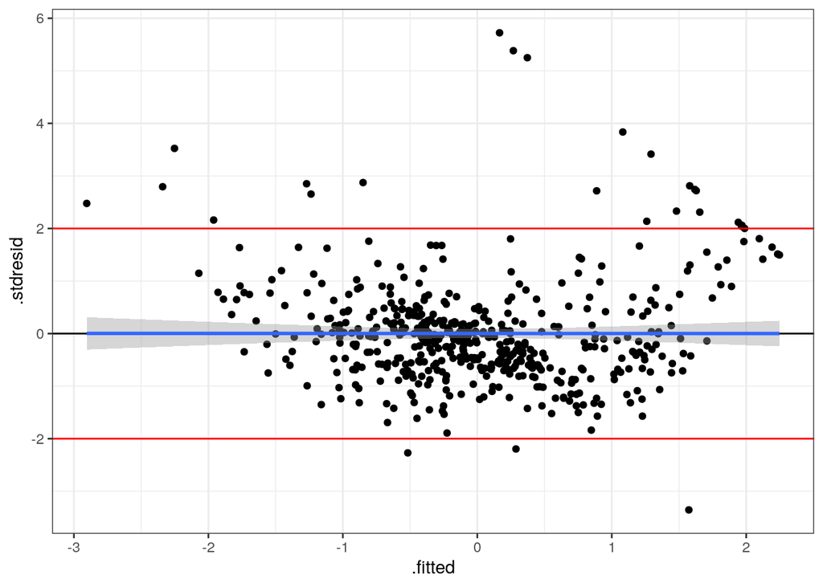

```r
mod_diag <- fortify(full_model)
gg_resid <- ggplot(data = mod_diag, aes(x = .fitted, y = .stdresid)) +
  geom_point() +
  geom_hline(yintercept = 0) +
  geom_smooth(method = "lm") +
  geom_hline(yintercept = 2, color = "red") +
  geom_hline(yintercept = -2, color = "red")

gg_resid
```

Сделаем определенные выводы:

- Модель обладает определенной линейностью взаимосвязи
- Относительно много наблюдений находятся за пределеами зоны +- 2 стандартных отклонения
- Гетероскедастичность отсутствует

Неплохо, но довольно сильные отклонения за пределы доверительного интервала смущают.

### 1.2.2 Проверка на выбросы

Для начала, подберём маржу, выход за границу которой будем считать выбросом. Ссылка, откуда взята формула - (https://www.rstatisticsblog.com/data-science-in-action/identifying-outliers/ (соответствующий раздел про расстояние Кука))

```r
metric <- 4/nrow(boston_standart)
```

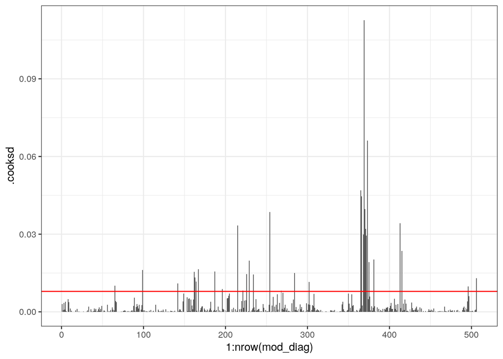

```r
ggplot(mod_diag, aes(x = 1:nrow(mod_diag), y = .cooksd)) +
  geom_bar(stat = "identity") +
  geom_hline(yintercept = metric, color = "red")
```

Обнаружим немалое количество выбросов.

### 1.2.3 Проверка на наличие независимых наблюдений

```r
durbinWatsonTest(full_model)
```

```
##  lag Autocorrelation D-W Statistic p-value
##    1       0.4512223      1.089005       0
##  Alternative hypothesis: rho != 0
```

Значение статистики автокорреляции значительно меньше двух. P value так и вовсе стремится к нулю. Таким образом, автокорреляция определенно присутствует.

### 1.2.4 Проверка на нормальность распределения

Построим квантиль-квантиль график:

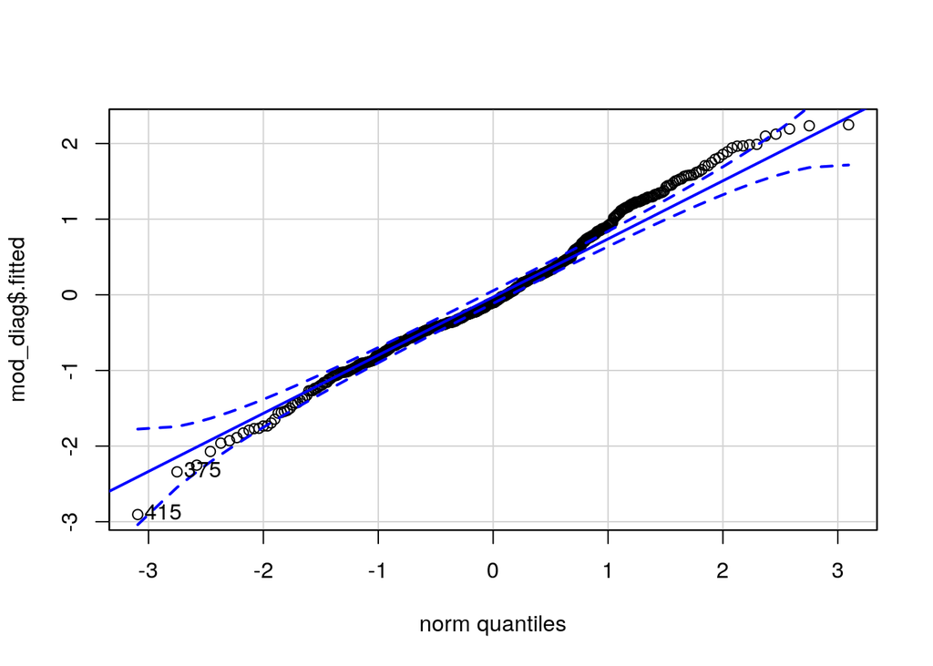

```
## [1] 415 375
```

```r
qqPlot(mod_diag$.fitted)
```

Делаем вывод об ассиметричности распределения - левый хвост распределения выходит более длинный. Распределение нельзя назвать нормальным.

## 1.3 Предсказания модели

Создадим тествовый датасет с предсказаниями:

```r
test_data_fm <- data.frame(
  lstat = seq(min(Boston$lstat), max(Boston$lstat), length.out = 506),
  crim = mean(Boston$crim),
  zn = mean(Boston$zn),
  indus = mean(Boston$indus),
  chas = as.factor(Boston$chas),
  nox = mean(Boston$nox),
  rm = mean(Boston$rm),
  age = mean(Boston$age),
  dis = mean(Boston$dis),
  rad = as.factor(Boston$rad),
  tax = mean(Boston$tax),
  ptratio = mean(Boston$ptratio),
  black = mean(Boston$black)
  )
```

Собственно, осуществим предсказания:

```r
predictions <- predict(full_model, newdata = test_data_fm,  interval = 'confidence')
test_data_fm <- cbind(test_data_fm, predictions)
```

И построим график с предсказаниями:

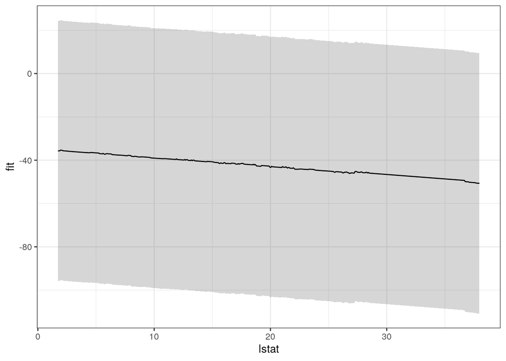

```r
ggplot(test_data_fm, aes(x = lstat, y = fit)) +
  geom_ribbon(alpha = 0.2, aes(ymin = lwr, ymax = upr)) +
  geom_line()
```

Та-да-а! Казалось бы, цель достигнута. Но…

# 2 Улучшение модели (Дополнительная часть)

## 2.1 Подбор оптимальной модели

### 2.1.1 Подбор модели

```r
summary(full_model)
```

```
##
## Call:
## lm(formula = medv ~ ., data = boston_standart)
##
## Residuals:
##      Min       1Q   Median       3Q      Max
## -1.64204 -0.29743 -0.04963  0.18289  2.82100
##
## Coefficients:
##              Estimate Std. Error t value Pr(>|t|)
## (Intercept) -0.458954   0.125554  -3.655 0.000285 ***
## crim        -0.101774   0.030569  -3.329 0.000937 ***
## zn           0.139209   0.035880   3.880 0.000119 ***
## indus        0.017723   0.047476   0.373 0.709081
## chas1        0.274452   0.093854   2.924 0.003614 **
## nox         -0.221410   0.049092  -4.510 8.13e-06 ***
## rm           0.280027   0.032177   8.703  < 2e-16 ***
## age          0.001411   0.040482   0.035 0.972210
## dis         -0.355919   0.046228  -7.699 7.75e-14 ***
## rad2         0.161888   0.160649   1.008 0.314095
## rad3         0.508992   0.145187   3.506 0.000498 ***
## rad4         0.280114   0.129102   2.170 0.030514 *
## rad5         0.317327   0.131303   2.417 0.016028 *
## rad6         0.128936   0.159182   0.810 0.418342
## rad7         0.530492   0.170836   3.105 0.002012 **
## rad8         0.526235   0.162188   3.245 0.001257 **
## rad24        0.811307   0.194483   4.172 3.58e-05 ***
## tax         -0.160310   0.071371  -2.246 0.025144 *
## ptratio     -0.228902   0.034009  -6.731 4.78e-11 ***
## black        0.093247   0.026411   3.531 0.000454 ***
## lstat       -0.410916   0.039319 -10.451  < 2e-16 ***
## ---
## Signif. codes:  0 '***' 0.001 '**' 0.01 '*' 0.05 '.' 0.1 ' ' 1
##
## Residual standard error: 0.5103 on 485 degrees of freedom
## Multiple R-squared:  0.7499, Adjusted R-squared:  0.7396
## F-statistic:  72.7 on 20 and 485 DF,  p-value: < 2.2e-16
```

```r
mod_1 <- update(full_model, .~. - chas)

summary(mod_1)
```

```
##
## Call:
## lm(formula = medv ~ crim + zn + indus + nox + rm + age + dis +
##     rad + tax + ptratio + black + lstat, data = boston_standart)
##
## Residuals:
##      Min       1Q   Median       3Q      Max
## -1.41352 -0.30667 -0.05221  0.18851  2.85723
##
## Coefficients:
##              Estimate Std. Error t value Pr(>|t|)
## (Intercept) -0.453252   0.126511  -3.583 0.000374 ***
## crim        -0.106168   0.030768  -3.451 0.000608 ***
## zn           0.141538   0.036149   3.915 0.000103 ***
## indus        0.032255   0.047581   0.678 0.498167
## nox         -0.216816   0.049446  -4.385 1.42e-05 ***
## rm           0.282209   0.032418   8.705  < 2e-16 ***
## age          0.006943   0.040751   0.170 0.864781
## dis         -0.359543   0.046569  -7.721 6.65e-14 ***
## rad2         0.128926   0.161494   0.798 0.425065
## rad3         0.509939   0.146310   3.485 0.000536 ***
## rad4         0.290065   0.130056   2.230 0.026183 *
## rad5         0.314954   0.132317   2.380 0.017683 *
## rad6         0.121767   0.160395   0.759 0.448119
## rad7         0.527362   0.172155   3.063 0.002311 **
## rad8         0.566048   0.162866   3.476 0.000555 ***
## rad24        0.856292   0.195374   4.383 1.44e-05 ***
## tax         -0.184171   0.071452  -2.578 0.010244 *
## ptratio     -0.240112   0.034054  -7.051 6.14e-12 ***
## black        0.097138   0.026582   3.654 0.000286 ***
## lstat       -0.417587   0.039557 -10.557  < 2e-16 ***
## ---
## Signif. codes:  0 '***' 0.001 '**' 0.01 '*' 0.05 '.' 0.1 ' ' 1
##
## Residual standard error: 0.5143 on 486 degrees of freedom
## Multiple R-squared:  0.7455, Adjusted R-squared:  0.7355
## F-statistic: 74.91 on 19 and 486 DF,  p-value: < 2.2e-16
```

```r
mod_2 <- update(mod_1, .~. - indus)

summary(mod_2)
```

```
##
## Call:
## lm(formula = medv ~ crim + zn + nox + rm + age + dis + rad +
##     tax + ptratio + black + lstat, data = boston_standart)
##
## Residuals:
##      Min       1Q   Median       3Q      Max
## -1.40699 -0.29805 -0.05462  0.18569  2.85612
##
## Coefficients:
##              Estimate Std. Error t value Pr(>|t|)
## (Intercept) -0.447129   0.126118  -3.545 0.000430 ***
## crim        -0.107199   0.030713  -3.490 0.000526 ***
## zn           0.137942   0.035738   3.860 0.000129 ***
## nox         -0.207364   0.047413  -4.374 1.50e-05 ***
## rm           0.279983   0.032233   8.686  < 2e-16 ***
## age          0.007022   0.040728   0.172 0.863183
## dis         -0.365792   0.045622  -8.018 8.05e-15 ***
## rad2         0.143362   0.159995   0.896 0.370673
## rad3         0.506089   0.146118   3.464 0.000580 ***
## rad4         0.296385   0.129650   2.286 0.022680 *
## rad5         0.311176   0.132126   2.355 0.018911 *
## rad6         0.109800   0.159332   0.689 0.491072
## rad7         0.526619   0.172056   3.061 0.002330 **
## rad8         0.557450   0.162281   3.435 0.000643 ***
## rad24        0.833347   0.192313   4.333 1.79e-05 ***
## tax         -0.163945   0.064888  -2.527 0.011834 *
## ptratio     -0.239163   0.034006  -7.033 6.89e-12 ***
## black        0.096672   0.026558   3.640 0.000302 ***
## lstat       -0.416125   0.039476 -10.541  < 2e-16 ***
## ---
## Signif. codes:  0 '***' 0.001 '**' 0.01 '*' 0.05 '.' 0.1 ' ' 1
##
## Residual standard error: 0.514 on 487 degrees of freedom
## Multiple R-squared:  0.7452, Adjusted R-squared:  0.7358
## F-statistic: 79.13 on 18 and 487 DF,  p-value: < 2.2e-16
```

```r
mod_3 <- update(mod_2, .~. - age)

summary(mod_3)
```

```
##
## Call:
## lm(formula = medv ~ crim + zn + nox + rm + dis + rad + tax +
##     ptratio + black + lstat, data = boston_standart)
##
## Residuals:
##      Min       1Q   Median       3Q      Max
## -1.40967 -0.29663 -0.05399  0.18382  2.85832
##
## Coefficients:
##             Estimate Std. Error t value Pr(>|t|)
## (Intercept) -0.44618    0.12587  -3.545 0.000431 ***
## crim        -0.10719    0.03068  -3.493 0.000520 ***
## zn           0.13733    0.03552   3.866 0.000126 ***
## nox         -0.20518    0.04564  -4.496 8.67e-06 ***
## rm           0.28102    0.03164   8.882  < 2e-16 ***
## dis         -0.36812    0.04354  -8.455 3.24e-16 ***
## rad2         0.14441    0.15972   0.904 0.366368
## rad3         0.50532    0.14590   3.463 0.000580 ***
## rad4         0.29562    0.12944   2.284 0.022816 *
## rad5         0.31120    0.13199   2.358 0.018785 *
## rad6         0.10837    0.15896   0.682 0.495719
## rad7         0.52538    0.17174   3.059 0.002341 **
## rad8         0.55888    0.16191   3.452 0.000605 ***
## rad24        0.83055    0.19144   4.339 1.74e-05 ***
## tax         -0.16335    0.06473  -2.523 0.011937 *
## ptratio     -0.23859    0.03381  -7.057 5.89e-12 ***
## black        0.09698    0.02647   3.664 0.000276 ***
## lstat       -0.41379    0.03704 -11.171  < 2e-16 ***
## ---
## Signif. codes:  0 '***' 0.001 '**' 0.01 '*' 0.05 '.' 0.1 ' ' 1
##
## Residual standard error: 0.5135 on 488 degrees of freedom
## Multiple R-squared:  0.7452, Adjusted R-squared:  0.7363
## F-statistic: 83.95 on 17 and 488 DF,  p-value: < 2.2e-16
```

### 2.1.2 Подбор модели без коллинеарности

Для этого используем критерий VIF (Variance inflation factor). Если VIF предиктора модели будет выше 2, то нам следует удалить этот предиктор. Если таких предикторов несколько, то нам следует аккуратно пошагово удалить все такие предикторы, пока VIF не будут менее двух.

Итак, запустим VIF:

```r
vif(mod_3)
```

```
##              GVIF Df GVIF^(1/(2*Df))
## crim     1.803063  1        1.342782
## zn       2.416986  1        1.554666
## nox      3.989326  1        1.997330
## rm       1.917201  1        1.384630
## dis      3.630122  1        1.905288
## rad     14.864116  8        1.183746
## tax      8.025150  1        2.832870
## ptratio  2.189533  1        1.479707
## black    1.341987  1        1.158442
## lstat    2.627918  1        1.621085
```

Похоже, что у VIF проблемы с расчётом для факторной переменной c большим количеством градаций. Уберём переменную rad:

```r
mod_4 <- update(mod_3, .~. - rad)
vif(mod_4)
```

```
##     crim       zn      nox       rm      dis      tax  ptratio    black
## 1.637904 2.227821 3.739342 1.771147 3.416214 2.939470 1.707813 1.331911
##    lstat
## 2.577849
```

Отлично. Получили несколько переменных с VIF > 2. Будем удалять VIF в порядке от максимального до минимального. Начнём с nox:

```r
mod_5 <- update(mod_4, .~. - nox)
vif(mod_5)
```

```
##     crim       zn       rm      dis      tax  ptratio    black    lstat
## 1.631215 2.200765 1.765391 2.614328 2.370906 1.551543 1.324862 2.470752
```

```r
mod_6 <- update(mod_5, .~. - dis)
vif(mod_6)
```

```
##     crim       zn       rm      tax  ptratio    black    lstat
## 1.621032 1.314391 1.707940 2.076903 1.453732 1.324732 2.353723
```

```r
mod_7 <- update(mod_6, .~. - lstat)
vif(mod_7)
```

```
##     crim       zn       rm      tax  ptratio    black
## 1.569280 1.258393 1.215943 1.953309 1.452810 1.287582
```

## 2.2 Диагностика модели

### 2.2.1 Коррекция модели

Создадим датасет с данными для анализа остатков и построим график остатков (не будем учитывать наши факторы):

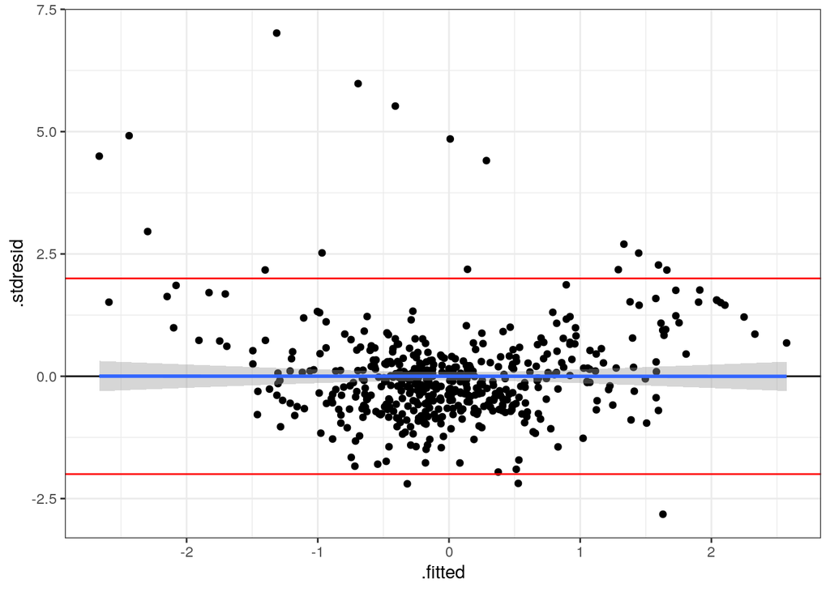

```r
mod_diag_adj <- data.frame(fortify(mod_7), boston_standart$lstat, boston_standart$dis,
                           boston_standart$nox, boston_standart$age,
                           boston_standart$indus)


gg_resid <- ggplot(data = mod_diag_adj, aes(x = .fitted, y = .stdresid)) +
  geom_point() +
  geom_hline(yintercept = 0) +
  geom_smooth(method = 'lm') +
  geom_hline(yintercept = 2, color = "red") +
  geom_hline(yintercept = -2, color = "red")
gg_resid
```

Сделаем определенные выводы:

- Модель обладает определенной линейностью взаимосвязи
- Относительно много (но на вид меньше, чем в предыдущей модели) наблюдений находятся за пределеами зоны +- 2 стандартных отклонения
- Гетероскедастичность отсутствует

Кроме того, построим такие же графики для удалённых переменных:

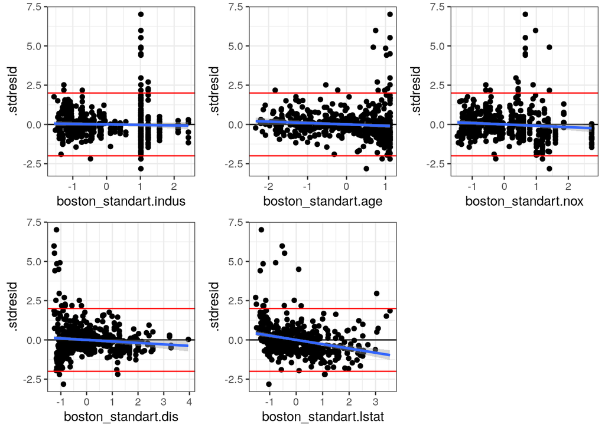

```r
res_1 <- gg_resid + aes(x = boston_standart.indus)
res_2 <- gg_resid + aes(x = boston_standart.age)
res_3 <- gg_resid + aes(x = boston_standart.nox)
res_4 <- gg_resid + aes(x = boston_standart.dis)
res_5 <- gg_resid + aes(x = boston_standart.lstat)

grid.arrange(res_1, res_2, res_3, res_4, res_5, nrow = 2)
```

Увидим неучтённые зависимости (dis и lstat) и вернём их в модель. Повторно проведём F тесты. Увидим, что от удаления age немного ухудшается исправленный R2 и вернём его назад:

```r
mod_8 <- update(mod_7, .~. + lstat + dis)
summary(mod_8)
```

```
##
## Call:
## lm(formula = medv ~ crim + zn + rm + tax + ptratio + black +
##     lstat + dis, data = boston_standart)
##
## Residuals:
##      Min       1Q   Median       3Q      Max
## -1.61529 -0.30063 -0.08493  0.17228  3.02163
##
## Coefficients:
##               Estimate Std. Error t value Pr(>|t|)
## (Intercept) -1.394e-16  2.404e-02   0.000 1.000000
## crim        -5.467e-02  3.074e-02  -1.779 0.075916 .
## zn           1.203e-01  3.570e-02   3.369 0.000814 ***
## rm           3.297e-01  3.198e-02  10.311  < 2e-16 ***
## tax         -7.113e-02  3.706e-02  -1.919 0.055503 .
## ptratio     -1.680e-01  2.998e-02  -5.604 3.47e-08 ***
## black        9.609e-02  2.770e-02   3.469 0.000569 ***
## lstat       -4.458e-01  3.783e-02 -11.783  < 2e-16 ***
## dis         -2.450e-01  3.891e-02  -6.297 6.68e-10 ***
## ---
## Signif. codes:  0 '***' 0.001 '**' 0.01 '*' 0.05 '.' 0.1 ' ' 1
##
## Residual standard error: 0.5408 on 497 degrees of freedom
## Multiple R-squared:  0.7121, Adjusted R-squared:  0.7075
## F-statistic: 153.7 on 8 and 497 DF,  p-value: < 2.2e-16
```

```r
mod_9 <- update(mod_8, .~. - age)
summary(mod_9)
```

```
##
## Call:
## lm(formula = medv ~ crim + zn + rm + tax + ptratio + black +
##     lstat + dis, data = boston_standart)
##
## Residuals:
##      Min       1Q   Median       3Q      Max
## -1.61529 -0.30063 -0.08493  0.17228  3.02163
##
## Coefficients:
##               Estimate Std. Error t value Pr(>|t|)
## (Intercept) -1.394e-16  2.404e-02   0.000 1.000000
## crim        -5.467e-02  3.074e-02  -1.779 0.075916 .
## zn           1.203e-01  3.570e-02   3.369 0.000814 ***
## rm           3.297e-01  3.198e-02  10.311  < 2e-16 ***
## tax         -7.113e-02  3.706e-02  -1.919 0.055503 .
## ptratio     -1.680e-01  2.998e-02  -5.604 3.47e-08 ***
## black        9.609e-02  2.770e-02   3.469 0.000569 ***
## lstat       -4.458e-01  3.783e-02 -11.783  < 2e-16 ***
## dis         -2.450e-01  3.891e-02  -6.297 6.68e-10 ***
## ---
## Signif. codes:  0 '***' 0.001 '**' 0.01 '*' 0.05 '.' 0.1 ' ' 1
##
## Residual standard error: 0.5408 on 497 degrees of freedom
## Multiple R-squared:  0.7121, Adjusted R-squared:  0.7075
## F-statistic: 153.7 on 8 and 497 DF,  p-value: < 2.2e-16
```

```r
mod_10 <- update(mod_9, .~. + age)
summary(mod_10)
```

```
##
## Call:
## lm(formula = medv ~ crim + zn + rm + tax + ptratio + black +
##     lstat + dis + age, data = boston_standart)
##
## Residuals:
##      Min       1Q   Median       3Q      Max
## -1.62581 -0.30364 -0.08055  0.17580  3.08195
##
## Coefficients:
##               Estimate Std. Error t value Pr(>|t|)
## (Intercept) -1.540e-16  2.403e-02   0.000 1.000000
## crim        -5.621e-02  3.074e-02  -1.829 0.068053 .
## zn           1.136e-01  3.605e-02   3.153 0.001714 **
## rm           3.371e-01  3.247e-02  10.384  < 2e-16 ***
## tax         -6.697e-02  3.717e-02  -1.801 0.072237 .
## ptratio     -1.689e-01  2.997e-02  -5.635 2.93e-08 ***
## black        9.784e-02  2.772e-02   3.530 0.000454 ***
## lstat       -4.256e-01  4.090e-02 -10.404  < 2e-16 ***
## dis         -2.704e-01  4.356e-02  -6.209 1.13e-09 ***
## age         -5.248e-02  4.055e-02  -1.294 0.196179
## ---
## Signif. codes:  0 '***' 0.001 '**' 0.01 '*' 0.05 '.' 0.1 ' ' 1
##
## Residual standard error: 0.5405 on 496 degrees of freedom
## Multiple R-squared:  0.7131, Adjusted R-squared:  0.7079
## F-statistic:   137 on 9 and 496 DF,  p-value: < 2.2e-16
```

Немного погрустим из-за того, что у нас ухудшился R2 (0.7079 у новой модели против 0.7363 у старой). Почему-то.

### 2.2.2 Проверка графиков остатков

Повторно построим график остатков:

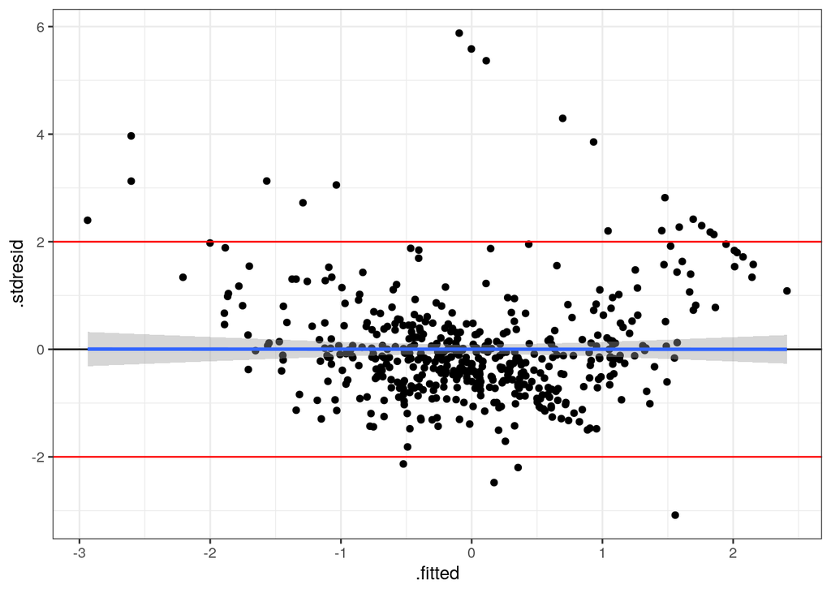

```r
mod_diag_adj <- data.frame(fortify(mod_10), boston_standart$dis,
                           boston_standart$nox, boston_standart$age,
                           boston_standart$indus)


gg_resid <- ggplot(data = mod_diag_adj, aes(x = .fitted, y = .stdresid)) +
  geom_point() +
  geom_hline(yintercept = 0) +
  geom_smooth(method = "lm") +
  geom_hline(yintercept = 2, color = "red") +
  geom_hline(yintercept = -2, color = "red")
gg_resid
```

Сделаем такой же вывод как и в прошлый раз:

- Модель обладает определенной линейностью взаимосвязи
- Относительно много (но на вид меньше, чем в предыдущей модели) наблюдений находятся за пределеами зоны +- 2 стандартных отклонения
- Гетероскедастичность отсутствует

### 2.2.3 Проверка на выбросы

```r
metric <- 4/nrow(boston_standart)
```

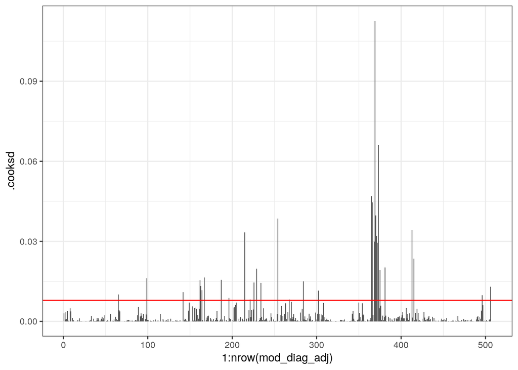

```r
ggplot(mod_diag, aes(x = 1:nrow(mod_diag_adj), y = .cooksd)) +
  geom_bar(stat = "identity") +
  geom_hline(yintercept = metric, color = "red")
```

### 2.2.4 Проверка на наличие независимых наблюдений

```r
durbinWatsonTest(mod_10)
```

```
##  lag Autocorrelation D-W Statistic p-value
##    1       0.5168357     0.9498004       0
##  Alternative hypothesis: rho != 0
```

### 2.2.5 Проверка на нормальность распределения

Построим квантиль-квантиль график:

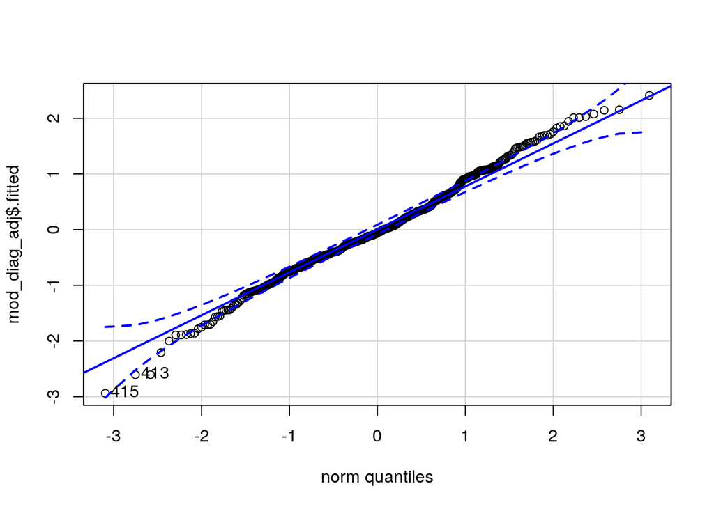

```
## [1] 415 413
```

```r
qqPlot(mod_diag_adj$.fitted)
```

## 2.3 Предсказания модели

Создадим тествовый датасет с предсказаниями:

```r
summary(mod_10)
```

```
##
## Call:
## lm(formula = medv ~ crim + zn + rm + tax + ptratio + black +
##     lstat + dis + age, data = boston_standart)
##
## Residuals:
##      Min       1Q   Median       3Q      Max
## -1.62581 -0.30364 -0.08055  0.17580  3.08195
##
## Coefficients:
##               Estimate Std. Error t value Pr(>|t|)
## (Intercept) -1.540e-16  2.403e-02   0.000 1.000000
## crim        -5.621e-02  3.074e-02  -1.829 0.068053 .
## zn           1.136e-01  3.605e-02   3.153 0.001714 **
## rm           3.371e-01  3.247e-02  10.384  < 2e-16 ***
## tax         -6.697e-02  3.717e-02  -1.801 0.072237 .
## ptratio     -1.689e-01  2.997e-02  -5.635 2.93e-08 ***
## black        9.784e-02  2.772e-02   3.530 0.000454 ***
## lstat       -4.256e-01  4.090e-02 -10.404  < 2e-16 ***
## dis         -2.704e-01  4.356e-02  -6.209 1.13e-09 ***
## age         -5.248e-02  4.055e-02  -1.294 0.196179
## ---
## Signif. codes:  0 '***' 0.001 '**' 0.01 '*' 0.05 '.' 0.1 ' ' 1
##
## Residual standard error: 0.5405 on 496 degrees of freedom
## Multiple R-squared:  0.7131, Adjusted R-squared:  0.7079
## F-statistic:   137 on 9 and 496 DF,  p-value: < 2.2e-16
```

```r
test_data_10 <- data.frame(
  lstat = seq(min(Boston$lstat), max(Boston$lstat), length.out = 506),
  crim = mean(Boston$crim),
  zn = mean(Boston$zn),
  rm = mean(Boston$rm),
  tax = mean(Boston$tax),
  ptratio = mean(Boston$ptratio),
  black = mean(Boston$black),
  age = mean(Boston$age),
  dis = mean(Boston$dis)
  )
```

Собственно, осуществим предсказания:

```r
predictions <- predict(mod_10, newdata = test_data_10,  interval = 'confidence')
test_data_10 <- cbind(test_data_10, predictions)
```

И построим график с предсказаниями:

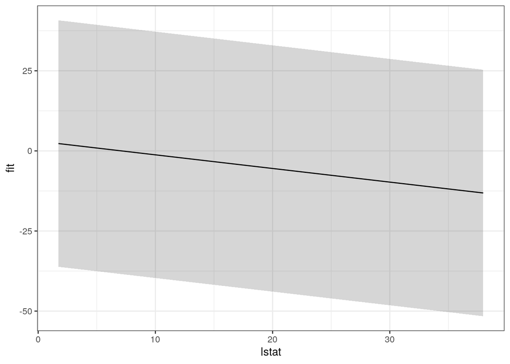

```r
ggplot(test_data_10, aes(x = lstat, y = fit)) +
  geom_ribbon(alpha = 0.2, aes(ymin = lwr, ymax = upr)) +
  geom_line()
```

## 2.4 Интерпретация модели

### 2.4.1 Статистика по модели

Ещё раз выведем summary от итоговой модели:

```r
summary(mod_10)
```

```
##
## Call:
## lm(formula = medv ~ crim + zn + rm + tax + ptratio + black +
##     lstat + dis + age, data = boston_standart)
##
## Residuals:
##      Min       1Q   Median       3Q      Max
## -1.62581 -0.30364 -0.08055  0.17580  3.08195
##
## Coefficients:
##               Estimate Std. Error t value Pr(>|t|)
## (Intercept) -1.540e-16  2.403e-02   0.000 1.000000
## crim        -5.621e-02  3.074e-02  -1.829 0.068053 .
## zn           1.136e-01  3.605e-02   3.153 0.001714 **
## rm           3.371e-01  3.247e-02  10.384  < 2e-16 ***
## tax         -6.697e-02  3.717e-02  -1.801 0.072237 .
## ptratio     -1.689e-01  2.997e-02  -5.635 2.93e-08 ***
## black        9.784e-02  2.772e-02   3.530 0.000454 ***
## lstat       -4.256e-01  4.090e-02 -10.404  < 2e-16 ***
## dis         -2.704e-01  4.356e-02  -6.209 1.13e-09 ***
## age         -5.248e-02  4.055e-02  -1.294 0.196179
## ---
## Signif. codes:  0 '***' 0.001 '**' 0.01 '*' 0.05 '.' 0.1 ' ' 1
##
## Residual standard error: 0.5405 on 496 degrees of freedom
## Multiple R-squared:  0.7131, Adjusted R-squared:  0.7079
## F-statistic:   137 on 9 and 496 DF,  p-value: < 2.2e-16
```

Построим красивую табличку для статьи:

```r
summary(mod_10) %>% xtable() %>% kable %>% kable_styling()
```

|  | Estimate | Std. Error | t value | Pr(>\|t\|) |
| --- | --- | --- | --- | --- |
| (Intercept) | 0.0000000 | 0.0240272 | 0.000000 | 1.0000000 |
| crim | -0.0562140 | 0.0307408 | -1.828647 | 0.0680529 |
| zn | 0.1136476 | 0.0360454 | 3.152898 | 0.0017145 |
| rm | 0.3371447 | 0.0324669 | 10.384263 | 0.0000000 |
| tax | -0.0669651 | 0.0371726 | -1.801463 | 0.0722371 |
| ptratio | -0.1688700 | 0.0299654 | -5.635497 | 0.0000000 |
| black | 0.0978388 | 0.0277164 | 3.529998 | 0.0004543 |
| lstat | -0.4255552 | 0.0409024 | -10.404154 | 0.0000000 |
| dis | -0.2704362 | 0.0435573 | -6.208739 | 0.0000000 |
| age | -0.0524819 | 0.0405498 | -1.294257 | 0.1961789 |

Исправленный R2 = 0.7079

Матрица корреляций для изначальных данных:

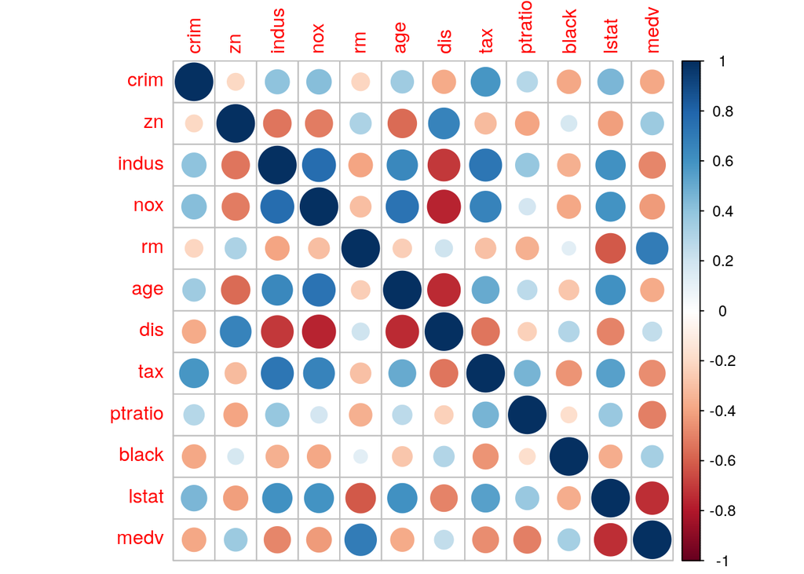

```r
mat <- cor(boston_standart[ , purrr::map_lgl(boston_standart, is.numeric)])
corrplot(mat)
```

### 2.4.2 Выводы по качеству и дискуссия

Странно, но вопреки мероприятиям по исправлению качества, оно ухудшилось. Исправленный R2 = 0.7079 у новой модели против R2 = 0.7363 у старой. Возможно, это связано с попытками избавиться от мультиколлинеарности с помощью VIF. Вероятно, лучшей альтернативой было бы использование PCA.

Кроме того, вероятно, что само линейное моделирование для данного конкретного датасета - это не самое лучшее решение. Возможно, использование LASSO (least absolute shrinkage and selection operator) было бы более хорошим решением.